# Групповой проект. Тема: Рост дендритов

Этап 1

Артамонов Т. Е.,

Федорина Э. В.,

Морозов М. E.,

Коротун И. И.,

Маслова А. С.

Российский Университет Дружбы Народов, Moscow, Russian Federation

24 февраля 2024

# Информация

## Состав исследовательской команды

Студенты группы НКНбд-01-21

- Артамонов Тимофей Евгеньевич
- Федорина Эрнест Васильевич
- Морозов Михаил Евгеньвич
- Коротун Илья Игоревич
- Маслова Анастасия Сергеевна

# Вводная часть

## Определение

Дендриты — это древовидные кристаллические структуры, которые образуются в процессе кристаллизации из переохлажденного расплава. Они играют ключевую роль в определении микроструктуры и, следовательно, физических свойств материалов.

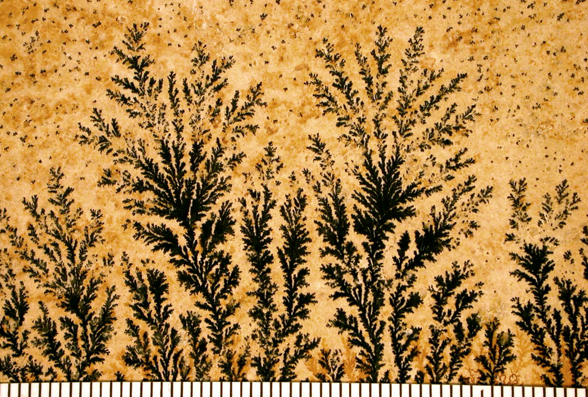

Дендриты марганца

## Определение

Процесс роста дендритов зависит от множества факторов. Если исследовать механизм формирования дендритов, то можно научиться изменять свойства различных сплавов, а значит исследование полезно не только для теории, но и для практики.

# Формирование и описание научной проблемы

## Проблема управления и предсказания морфологии дендритной кристаллизации в переохлажденных расплавах

В процессе формирования кристаллических структур из переохлажденных расплавов ключевым является понимание и управление механизмами роста дендритов, поскольку именно они определяют конечные физические свойства материалов. Дендритный рост, происходящий в результате кристаллизации, существенно влияет на микроструктуру и, как следствие, на механические, электрические и тепловые характеристики материалов.

[figure not shown]

## Проблема управления и предсказания морфологии дендритной кристаллизации в переохлажденных расплавах

Таким образом, научная проблема заключается в разработке теоретических и численных моделей, способных точно предсказывать динамику роста дендритов и их влияние на микроструктуру сформированных материалов.

## Актуальность

Решение этой проблемы откроет новые возможности для оптимизации процессов производства материалов с высокими эксплуатационными характеристиками и для создания новых материалов с уникальными свойствами.

## Задачи

- Написать программу, моделирующую теплопроводность. Задать начальную температуру равной нулю везде, кроме центральной точки и посмотреть, как меняется распределение температуры.
- Добавить затвердевание, исследовать влияние начального переохлаждения S и величины капиллярного радиуса λ на форму образующихся дендритов.
- Исследовать зависимость от времени числа частиц в агрегате и его среднеквадратичного радиуса в разных режимах.
- Определить фрактальную размерность полученных образцов
- Исследуйте, как влияет величина теплового шума δ на вид образующихся агрегатов.

# Важные формулы

- **Безразмерное переохлаждение:**
  $$S = \frac{c_p (T_m -
  T_\infty)}{L}$$
- **Уравнение теплопроводности:**
  $$\rho c_p \frac{\partial T}{\partial t} = \kappa
  \nabla^2 T$$
- **Условие Стефана для скорости (V):**
  $$V = \frac{\kappa}{\rho L} (\nabla T|_s - \nabla
  T|_l)$$

# Важные формулы

## Выводы

Во время выполнения первого этапа группового проекта мы сделали теоретическое описание модели “Рост дендритов”, аналитически исследовали её и поставили задачу нашей работы.

## Список литературы

1. Д. А. Медведев, А. Л. Куперштох, Э. Р. Прууэл, Н. П. Сатонкина, Д. И. Карпов. МОДЕЛИРОВАНИЕ ФИЗИЧЕСКИХ ПРОЦЕССОВ И ЯВЛЕНИЙ НА ПК учебное пособие. НГУ, 2010. 91-96с.
2. Дендрит(кристалл) [Электронный ресурс]. Wikimedia Foundation, Inc., 2024. URL: Дендрит(кристалл)